## West Nile Disease Prediction

### Introduction to Background

This is a Kaggle competition project from two years ago. This project aims to predict the existence of virus spread by mosquitoes around different locations in Chicago area by using data including the weather conditions, locations of longitude, latitude, the adresses of the blocks, species of mosquitoes, the trap types implemented for reducing the number of mosquitoes, and so on. The time frame of the data is from the end of May, 2007 to the end of September, 2013. The data has also included a file that described when and where were spray used to kill the mosquitoes, but only dated between 2011 and 2013 over two years, which could not match the time frame of our existing data. Thus, I will not use the spray data in order to complete this project.

Reading in the data, the missing data are converted to 0:

```r
library(ggmap)
```

```r
data_dir <- "../input"
wnv <- read.csv(file.path(data_dir, "train.csv"))

spray <- read.csv(file.path(data_dir, "spray.csv"))

weather <- read.csv(file.path(data_dir, "weather.csv"))
for (j in 3:ncol(weather)) {
  weather[,j] <- as.numeric(weather[,j])
  weather[is.na(weather[,j]),j] <- 0
}

mapdata <- readRDS(file.path(data_dir, "mapdata_copyright_openstreetmap_contributors.rds"))
```

This step is to split the data into two groups including training group and validation group, with probabilities of 0.7 and 0.3 respectively. Setting seed equal to 1 here makes sure that each time when I run this step, the data will be split into two exactly same groups.

```r
set.seed(1)
wnv$train_id <- sample(c("train", "valid"),
                            nrow(wnv),
                            replace = TRUE,
                            prob = c(0.7, 0.3))
```

Since the species and trap types are presented in words, so this step here is to transform these two features into numeric values. Then each unique type is matched to its own ID in numbers.

```r
Species_ID <- unique(wnv$Species)
wnv$Species_ID <- match(wnv$Species, Species_ID)

Trap_ID <- unique(wnv$Trap)
wnv$Trap_ID <- match(wnv$Trap, Trap_ID)
```

Since the weather data is given in a separate file, I used this step to combine the weather data to the main data file. There are two versions of weather data collected by two stations. I only used the data collected by station 1 because the data collected by two stations are similar and I doubt if there will be any significant difference if using data collected by both stations. The data is filtered by dates and then matched to each column into the main data file according to specific dates.

```r
library(dplyr)
library(smodels)
wnv <- inner_join(wnv, filter(weather, Station == 1),
                 by = "Date")
```

Let’s take a look at what our data looks like! For details: Tmax, Tmin, Tavg, Depart, DewPoint, WetBulb are are all temperature measures measured in degrees Fahrenheit; CodeSum is the sum of significant weather type that are represented in numeric values including rain, thunderstorm, duststorm and such; water, snowfall, preciptotal are measured in inches; ResultSpeed stands for resultant wind speed; ResultDir stands for resultant wind direction.

```r
head(wnv, n=5)
```

```
##         Date                                            Address
## 1 2007-05-29 4100 North Oak Park Avenue, Chicago, IL 60634, USA
## 2 2007-05-29 4100 North Oak Park Avenue, Chicago, IL 60634, USA
## 3 2007-05-29  6200 North Mandell Avenue, Chicago, IL 60646, USA
## 4 2007-05-29    7900 West Foster Avenue, Chicago, IL 60656, USA
## 5 2007-05-29    7900 West Foster Avenue, Chicago, IL 60656, USA
##                  Species Block          Street Trap
## 1 CULEX PIPIENS/RESTUANS    41  N OAK PARK AVE T002
## 2         CULEX RESTUANS    41  N OAK PARK AVE T002
## 3         CULEX RESTUANS    62   N MANDELL AVE T007
## 4 CULEX PIPIENS/RESTUANS    79    W FOSTER AVE T015
## 5         CULEX RESTUANS    79    W FOSTER AVE T015
##              AddressNumberAndStreet Latitude Longitude AddressAccuracy
## 1 4100  N OAK PARK AVE, Chicago, IL 41.95469 -87.80099               9
## 2 4100  N OAK PARK AVE, Chicago, IL 41.95469 -87.80099               9
```

[output cut: 27 more lines]

Here’s where we have measurement points for some dates in the training data. The locations that we measure are displayed by the longitude and latitude given. From the graph below, we can clearly see that this is the Chicago area!

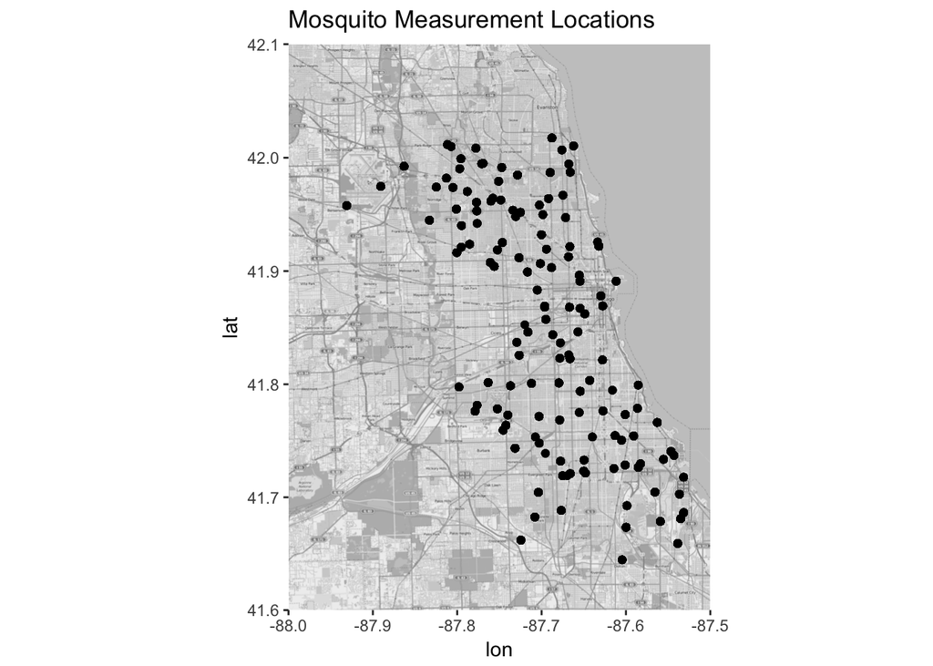

```r
# Shows where there are measurement points
ggmap(mapdata) +
  geom_point(aes(x=Longitude, y=Latitude), data=wnv) +
  ggtitle("Mosquito Measurement Locations")
```

### Clarification

This project requires a two-class prediction. Since the data is extremely unbalanced, with only nearly 5.25% are positive predictions, it is extremely difficult to improve the prediction accuracy because most models will just predict the existence of virus negatively and thus give predictions in 0. Therefore, I built up the models to predict continuous probabilities instead of classes, and used rmse to evaluate the accuracy of predictions.

### 1: Multinomial Regression

The first model I used is the multinomial regression model. This model uses several 6-degree polynomials combines, and emphasizes the interactions between certain variables like longitude and latitude, Tmax and Tmin. The rmse for validation set is around 0.22.

```r
library(nnet)
model <- multinom(WnvPresent ~ poly(Longitude, Latitude, degree = 6) + poly(Tmax, Tmin, degree = 6) + poly(Heat, Cool, degree = 6) +poly(Sunrise, Sunset, degree = 6) + poly(PrecipTotal, degree = 6) + poly(SeaLevel, degree = 6) + poly(AvgSpeed, degree = 6),
                  data = wnv)
wnv$wnv_pred <- predict(model, newdata = wnv, type = "probs")

sqrt(tapply((wnv$wnv_pred - wnv$WnvPresent)^2, wnv$train_id, mean))
```

```
##     train     valid
## 0.2066667 0.2197117
```

### 2: Nearest Neighbors

```r
library(FNN)
```

```r
X <- as.matrix(select(wnv, Longitude, Latitude))
X <- scale(X)
y <- wnv$WnvPresent
X_train <- X[wnv$train_id == "train",]
X_valid <- X[wnv$train_id == "valid",]
y_train <- y[wnv$train_id == "train"]
y_valid <- y[wnv$train_id == "valid"]
```

```r
wnv$wnv_pred <- knn.reg(train = X_train, test = X,
                     y = y_train, k = 50)$pred
```

```r
sqrt(tapply((wnv$wnv_pred - wnv$WnvPresent)^2, wnv$train_id, mean))
```

```
##     train     valid
## 0.2171082 0.2322914
```

This step is used to tune k nearest neighbors in order to find an appropriate k. As we can see from the graph below, the rmse does not differ too much as k becomes larger. Thus an apporiate k would be just the point at which the rmse stop decreasing.

```r
rmse <- rep(NA, 100)
for (k in seq_along(rmse)) {
  y_valid_pred <- knn.reg(train = X_train, y = y_train,
                          test = X_valid, k = k)$pred
  rmse[k] <- sqrt( mean((y_valid_pred - y_valid)^2) )
}
```

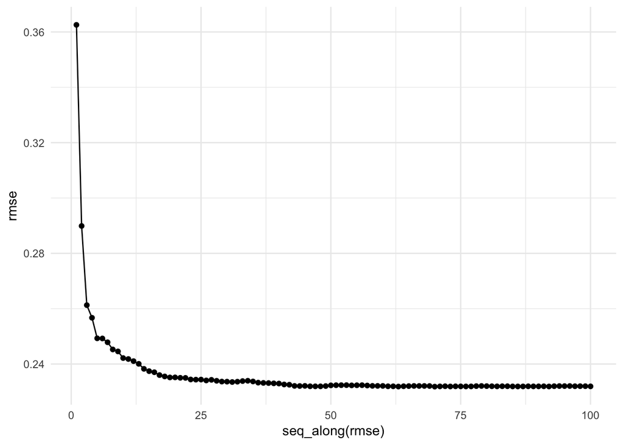

```r
qplot(seq_along(rmse), rmse) +
  geom_line() +
  theme_minimal()
```

### 3: Elastic Net

What we learn from the elastic net is that the number of mosquitos in one area is the most important feature for predicting the existence of virus. Then the DewPoint, Sunset and Sunrise is also important.

```r
X <- model.matrix(~ . - 1, data = wnv[,-c(1:7,12:13, 16, 37)])
y <- wnv$WnvPresent

X_train <- X[wnv$train_id == "train",]
y_train <- y[wnv$train_id == "train"]
X_valid <- X[wnv$train_id == "valid",]
y_valid <- y[wnv$train_id == "valid"]
```

```r
library(glmnet)
model <- cv.glmnet(X_train, y_train, alpha = 0.05)
wnv$wnv_pred <- predict(model, newx = X)
beta <- coef(model, s = c(model$lambda.min, model$lambda.1se, model$lambda[c(3, 10)]))
beta[beta[,2] != 0,]
```

```
## 5 x 4 sparse Matrix of class "dgCMatrix"
##                          1             2            3             4
## (Intercept)  -1.160090e+01  3.747772e-02 0.0489413194  3.747772e-02
## NumMosquitos  2.586347e-03  5.634057e-04 0.0001086089  5.634057e-04
## DewPoint      3.424932e-04  1.154184e-04 .             1.154184e-04
## Sunrise      -1.346779e-03  5.214390e-05 .             5.214390e-05
## Sunset       -2.464273e-03 -3.811614e-05 .            -3.811614e-05
```

```r
sqrt(tapply((wnv$wnv_pred - wnv$WnvPresent)^2, wnv$train_id, mean))
```

```
##     train     valid
## 0.2168454 0.2302854
```

### 4: Gradient Boosted Trees

```r
library(xgboost)
X <- model.matrix(~ . - 1, data = wnv[,-c(1:7,12:13, 16, 37)])
y <- wnv$WnvPresent

X_train <- X[wnv$train_id == "train",]
y_train <- y[wnv$train_id == "train"]
X_valid <- X[wnv$train_id == "valid",]
y_valid <- y[wnv$train_id == "valid"]
```

```r
data_train <- xgb.DMatrix(data = X_train, label = y_train)
data_valid <- xgb.DMatrix(data = X_valid, label = y_valid)
watchlist <- list(train=data_train, valid=data_valid)
```

```r
model <- xgb.train(data = data_train,
                 max_depth = 4, eta = 0.005, nthread = 3,
                 nrounds = 1800, objective = "reg:linear",
                 watchlist = watchlist,
                 print_every_n = 100)
importance_matrix <- xgb.importance(model = model)
importance_matrix[,1] <- colnames(X)[as.numeric(importance_matrix[[1]]) + 1]
importance_matrix
```

```
##             Feature         Gain        Cover    Frequency
##  1:    NumMosquitos 2.508372e-01 1.992162e-01 2.315346e-01
##  2:         Sunrise 2.332959e-01 1.210521e-01 1.276345e-01
##  3:        Latitude 1.196483e-01 1.288124e-01 1.127862e-01
##  4:       Longitude 1.140412e-01 7.939641e-02 9.752022e-02
##  5:        AvgSpeed 5.395316e-02 2.371308e-02 3.284852e-02
##  6:         Trap_ID 4.734875e-02 1.115351e-01 9.011506e-02
##  7:        DewPoint 2.781455e-02 3.030164e-02 3.444347e-02
##  8:         CodeSum 1.879035e-02 1.536816e-02 1.386093e-02
##  9:       ResultDir 1.851472e-02 3.282693e-02 3.246877e-02
## 10:            Tmin 1.763086e-02 3.190773e-02 3.774731e-02
## 11:         WetBulb 1.689571e-02 1.773592e-02 1.777238e-02
## 12:            Tmax 1.636970e-02 2.420594e-02 3.793719e-02
## 13:     PrecipTotal 1.465616e-02 1.077583e-02 1.405081e-02
## 14:     ResultSpeed 1.455510e-02 5.142059e-02 3.201306e-02
## 15:      Species_ID 1.188178e-02 2.903600e-02 2.882315e-02
## 16: AddressAccuracy 7.142446e-03 1.962868e-02 1.226598e-02
## 17:          Depart 6.548162e-03 2.738700e-02 1.788630e-02
## 18:            Tavg 4.935569e-03 2.695685e-02 1.553184e-02
## 19:        SeaLevel 2.652171e-03 6.107746e-03 6.607679e-03
## 20:     StnPressure 2.364697e-03 8.515647e-03 4.898796e-03
## 21:          Sunset 1.202356e-04 4.099988e-03 1.215205e-03
## 22:            Heat 3.194291e-06 1.529968e-07 3.797516e-05
##             Feature         Gain        Cover    Frequency
```

```r
wnv$wnv_pred <- predict(model, newdata = X)

sqrt(tapply((wnv$wnv_pred - wnv$WnvPresent)^2, wnv$train_id, mean))
```

```
##     train     valid
## 0.1830009 0.2145104
```

### 5: Generalize Additive Models

I chose the variables in this model according to the importance matrix generated by the previous gradient boosted trees model. This model paid attention to the interaction between longitude and latitude, and the interaction between the maximum and minimum temperatures. Well…this model does not beat the gradient boosted trees model!

```r
library(gam)
model <- gam(WnvPresent ~ lo(Longitude, Latitude) + s(Sunrise) + s(NumMosquitos) + s(Trap_ID) + s(Species_ID) + s(AvgSpeed) + lo(Tmax, Tmin) + s(Tavg) + s(ResultDir) + s(DewPoint) + s(PrecipTotal),
             data = wnv,
             subset = (train_id == "train"))
wnv$wnv_pred <- predict(model, newdata = wnv)

sqrt(tapply((wnv$wnv_pred - wnv$WnvPresent)^2, wnv$train_id, mean))
```

```
##     train     valid
## 0.2065273 0.2194826
```

### 6: Keras

```r
library(keras)
X_train <- X[wnv$train_id == "train",]
y_train <- to_categorical(y[wnv$train_id == "train"], num_classes = 2)
```

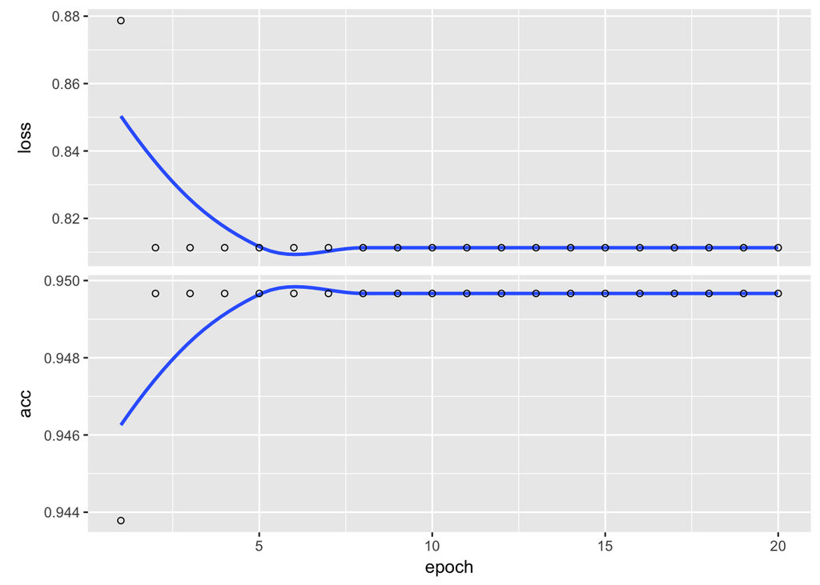

```r
model <- keras_model_sequential()
model %>%
  layer_dense(units = 256, input_shape = ncol(X_train)) %>%
  layer_activation(activation = "relu") %>%
  layer_dropout(rate = 0.5) %>%

  layer_dense(units = 256) %>%
  layer_activation(activation = "relu") %>%
  layer_dropout(rate = 0.5) %>%

  layer_dense(units = 2) %>%
  layer_activation(activation = "softmax")
model %>% compile(loss = 'categorical_crossentropy',
                  optimizer = optimizer_rmsprop(lr = 0.0005),
                  metrics = c('accuracy'))

history <- model %>%
  fit(X_train, y_train, epochs = 20)
plot(history)
```

```r
wnv$wnv_pred <- predict(model, X)[,1]
table(wnv$wnv_pred)
```

```
##
##     1
## 10506
```